# Portfolio 2: growthcurver

Justine Lang

2024-01-16

```r
knitr::opts_chunk$set(echo = TRUE, warning = FALSE, results = FALSE, message = FALSE)

library(tidyverse)
library(janitor)
library(here)
library(growthcurver) ### older logistic growth package
```

### Portfolio 2 Questions

Use ‘growthcurver’ package in R: Use World data

1. Import the global population data and apply the logistic growth model. Does the model describe the world population well?
2. Choose a country of interest. Does the model describe that country’s population well? What countries have logistic growth?

What the package does: Fits the logistic equation to microbial growth curve data (e.g., repeated absorbance measurements taken from a plate reader over time). From this fit, a variety of metrics are provided, including the maximum growth rate, the doubling time, the carrying capacity, the area under the logistic curve, and the time to the inflection point.

More simply, it’s useful for estimating growth rate and carrying capacity.

**Exponential Growth of Human Population Example**

```r
#get the data
w_pop_data<-read_csv(here("Portfolio1","population-and-demography.csv"))

#clean the data for only the global human population
w_pop_data<- w_pop_data |> clean_names() |>
  filter(country_name=="World") |>
  select(year, population) |> drop_na()
```

Always plot your data:

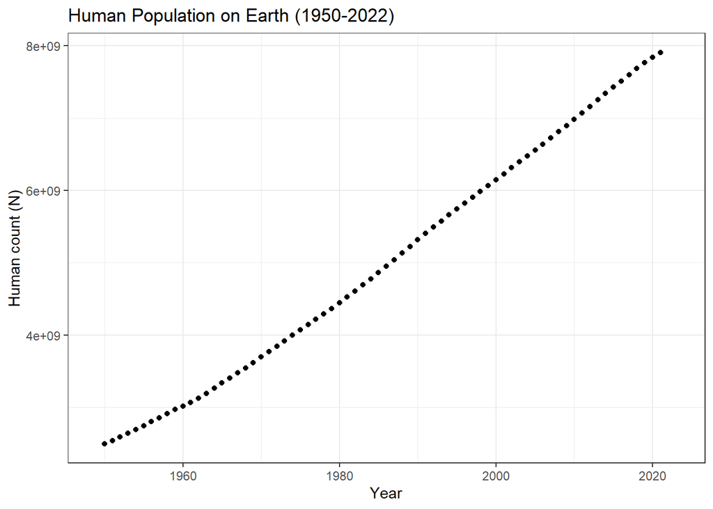

```r
#On the observed scale
human_ts<-ggplot(w_pop_data, aes(x=year, y=population))+
  geom_point()+
  xlab("Year")+
  ylab("Human count (N)")+
  xlim(1949, 2023)+
  ggtitle("Human Population on Earth (1950-2022)")+
  theme_bw()

human_ts
```

Fairly linear.

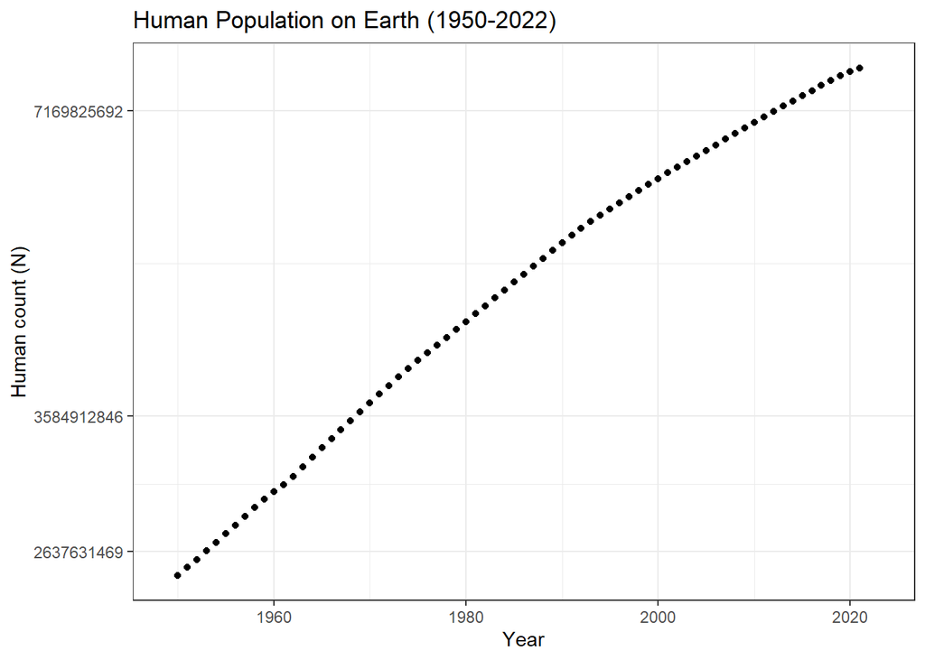

```r
#on the transformed log scale
human_ts_log<-ggplot(w_pop_data, aes(x=year, y=population))+
  geom_point()+
  xlab("Year")+
  ylab("Human count (N)")+
  scale_y_continuous(trans="log")+ # log scale for linear transformation
  xlim(1949, 2023)+
  ggtitle("Human Population on Earth (1950-2022)")+
  theme_bw()

human_ts_log
```

Also fairly linear.

Use lm() to find estimates:

```r
human.lm_fit<- lm(log(population)~year,data=w_pop_data)
summary(human.lm_fit) #how well does it fit?

NO<-exp(human.lm_fit$coefficients[1])
r<-human.lm_fit$coefficients[2]
```

The R-squared and p-value suggest a good fit, which makes sense based on how the plot looks. The question is if this is the best way to examine the data, depending on the question being asked.

Plot the data and the model:

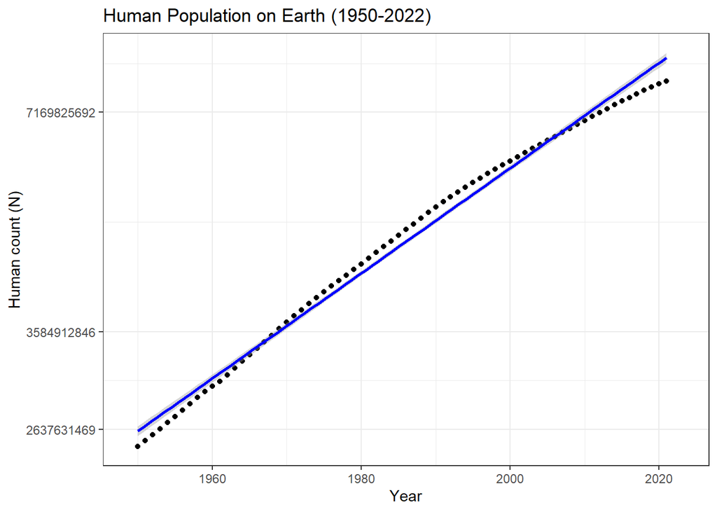

```r
# On the transformed scale
human_ts_model_trans<-ggplot(w_pop_data, aes(x=year, y=population))+
  geom_point()+
  xlab("Year")+
  ylab("Human count (N)")+
  scale_y_continuous(trans="log")+
  geom_smooth(method="lm",color="blue")+
  xlim(1949, 2023)+
  ggtitle("Human Population on Earth (1950-2022)")+
  theme_bw()

human_ts_model_trans
```

There are a couple places where the model over or underestimates the observed values, but it doesn’t look like a bad fit.

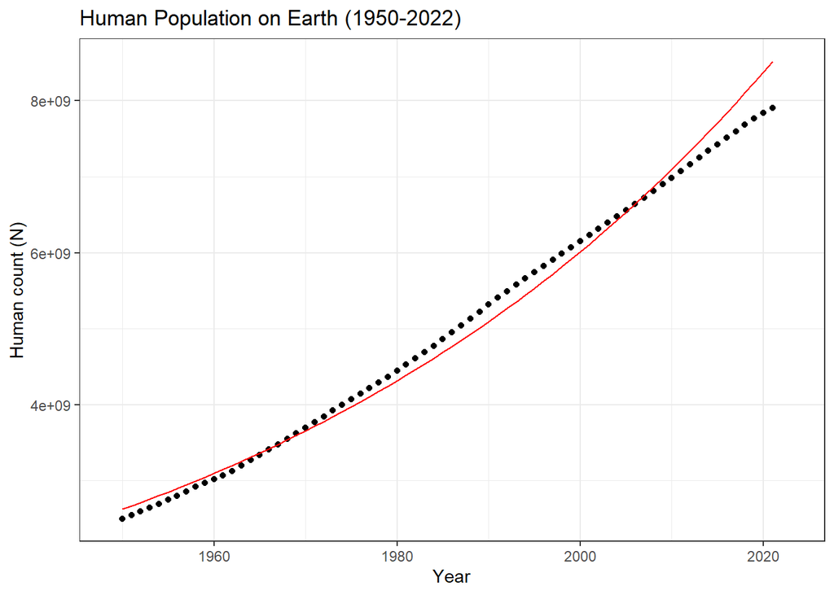

```r
# On the observed scale

# Predicted population values from the model
predicted_df <- data.frame(pop_pred = predict(human.lm_fit, w_pop_data), year=w_pop_data$year)
predicted_df<- predicted_df |> mutate(N_est=exp(pop_pred)) #transformed back to observed population estimates


human_ts_model<-ggplot(w_pop_data, aes(x=year, y=population))+
  geom_point(color="black")+
  geom_line(color='red',data = predicted_df, aes(x=year, y=N_est))+
  xlab("Year")+
  ylab("Human count (N)")+
  xlim(1949, 2023)+
  ggtitle("Human Population on Earth (1950-2022)")+
  theme_bw()

human_ts_model
```

**Exponential Growth of Denmark Population**

Let’s do the same thing but with a single country: Denmark.

```r
w_pop <-read_csv(here("Portfolio1","population-and-demography.csv"))

#clean the data for only the global human population
den_data<- w_pop |> clean_names() |>
  filter(country_name=="Denmark") |>
  select(year, population) |> drop_na()
```

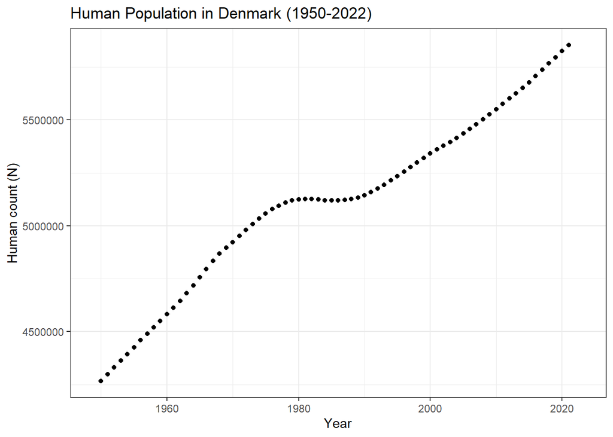

```r
#On the observed scale
denmark_ts<-ggplot(den_data, aes(x=year, y=population))+
  geom_point()+
  xlab("Year")+
  ylab("Human count (N)")+
  xlim(1949, 2023)+
  ggtitle("Human Population in Denmark (1950-2022)")+
  theme_bw()

denmark_ts
```

Overall positive trend, though there’s an odd place where the population almost dips. A little bit of research into historical events and policies around the time doesn’t reveal a clear explanation. Might be worth poking around a bit more.

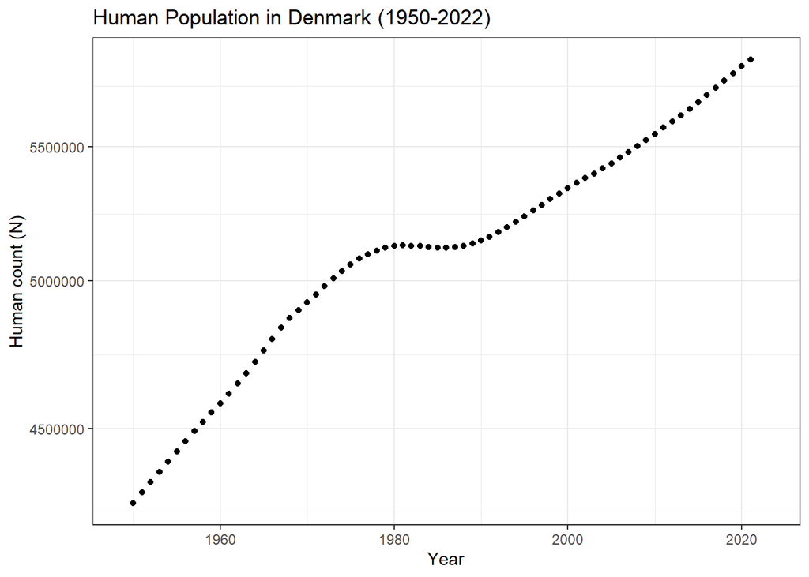

```r
#on the transformed log scale
denmark_ts_log<-ggplot(den_data, aes(x=year, y=population))+
  geom_point()+
  xlab("Year")+
  ylab("Human count (N)")+
  scale_y_continuous(trans="log")+ # log scale for linear transformation
  xlim(1949, 2023)+
  ggtitle("Human Population in Denmark (1950-2022)")+
  theme_bw()

denmark_ts_log
```

```r
denmark.lm_fit<- lm(log(population)~year,data=den_data)
summary(denmark.lm_fit) #how well does it fit?

den_NO<-exp(denmark.lm_fit$coefficients[1])
den_r<-denmark.lm_fit$coefficients[2]
```

R-squared and p-value still suggest a good fit. Visually, I’m less sure because of that dip.

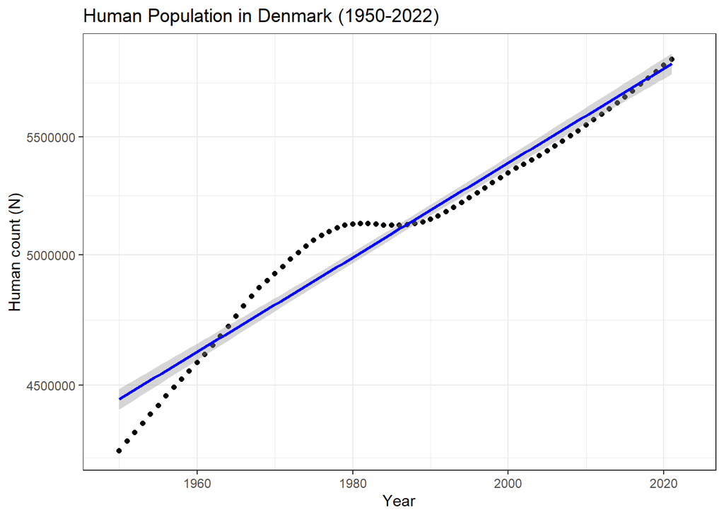

```r
# On the transformed scale
denmark_ts_model_trans<-ggplot(den_data, aes(x=year, y=population))+
  geom_point()+
  xlab("Year")+
  ylab("Human count (N)")+
  scale_y_continuous(trans="log")+
  geom_smooth(method="lm",color="blue")+
  xlim(1949, 2023)+
  ggtitle("Human Population in Denmark (1950-2022)")+
  theme_bw()

denmark_ts_model_trans
```

Some more obvious over and underestimation here.

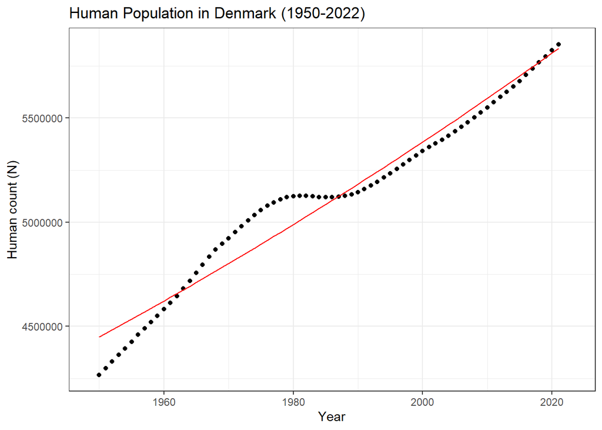

```r
# On the observed scale

# Predicted population values from the model
den_predicted_df <- data.frame(den_pop_pred = predict(denmark.lm_fit, den_data), year=den_data$year)
den_predicted_df<- den_predicted_df |> mutate(N_est=exp(den_pop_pred)) #transformed back to observed popualtion estimates


denmark_ts_model<-ggplot(den_data, aes(x=year, y=population))+
  geom_point(color="black")+
  geom_line(color='red',data = den_predicted_df, aes(x=year, y=N_est))+
  xlab("Year")+
  ylab("Human count (N)")+
  xlim(1949, 2023)+
  ggtitle("Human Population in Denmark (1950-2022)")+
  theme_bw()

denmark_ts_model
```

**Logistic Growth of Human and Bison Populations Example**

```r
#transform year to time for world pop data
w_pop_data <- w_pop_data |> mutate(time = year - year[1])
```

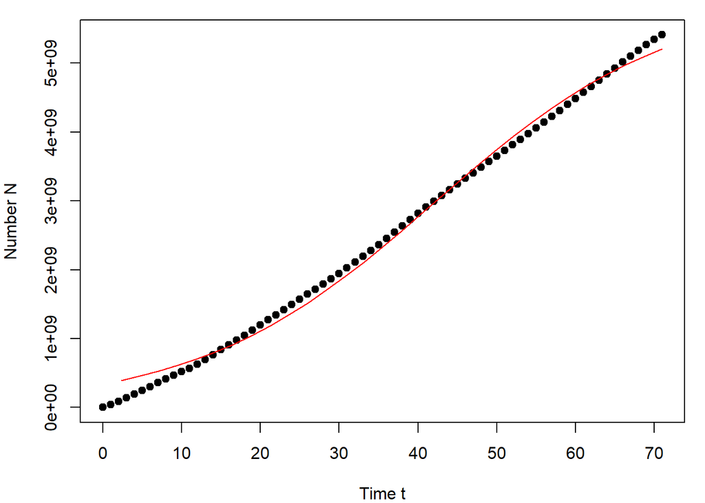

```r
#using the growthcurver package
#here: https://cran.r-project.org/web/packages/growthcurver/vignettes/Growthcurver-vignette.html

human_fit<-SummarizeGrowth(w_pop_data$time,w_pop_data$population)
human_fit
plot(human_fit) #what is funny with this graph?  N at 0 is what?
```

```r
w_pop_data$population[1] # need to add this to the y population values.
est_K_human<-human_fit$vals$k + w_pop_data$population[1] #estimated K for the data
```

Not a bad fit. r seems a bit higher with this model (0.067 as opposed to 0.0166). Important note: need to do a bit of addition to find K (see code).

Moving on to bison:

```r
#bison data
bison_data<-read_csv(here("Portfolio1","bison.csv"))

#transform year to time
bison_data <- bison_data |> mutate(time = year - year[1])
```

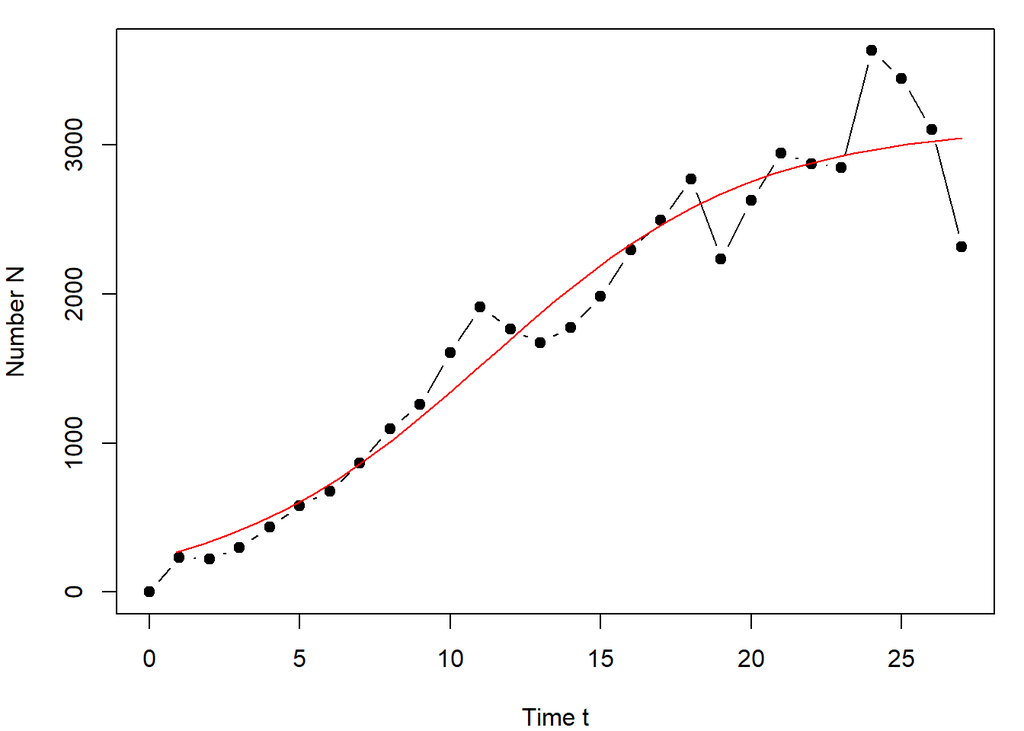

```r
bison_fit<-SummarizeGrowth(bison_data$time,bison_data$bison)
bison_fit
plot(bison_fit)
```

```r
est_K_bison<-bison_fit$vals$k + bison_data$bison[1] #estimated K for the data
```

Not a terrible fit, though the actual population growth isn’t that smooth. Important consideration: a lot of populations have natural fluctuations, which could influence what model you choose.

**Logistic Growth of Denmark Population**

Going back to Denmark:

```r
#transform year to time
den_data <- den_data |> mutate(time = year - year[1])
```

Remember time often has to start at 0. This is the case for other packages too.

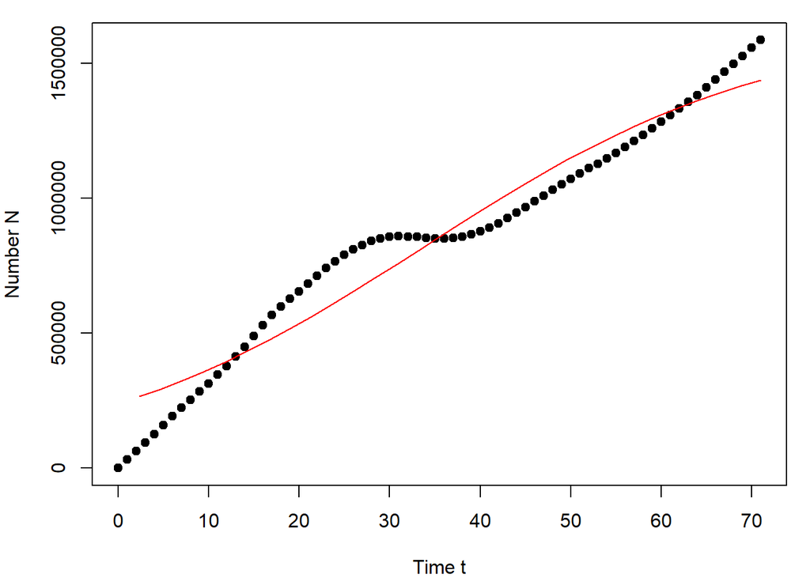

```r
denmark_fit<-SummarizeGrowth(den_data$time,den_data$population)
denmark_fit
plot(denmark_fit)
```

```r
den_data$population[1] # need to add this to the y population values.
est_K_denmark<-denmark_fit$vals$k + den_data$population[1] #estimated K for the data
```

Not a terrible fit but could be better. r is higher here too. K isn’t too far below the actual population of Denmark, which makes sense. Seems like a useful estimation, with some caveats.